# Teste 07

Grupo 03

# Exercício 4.26

Este conjunto de exercícios é referente ao banco de dados “CDI” utilizado em exercícios anteriores. Aqui, voltamos nossa atenção à regressão do número de médicos ativos utilizando a variável “total da população” como preditora.

## Item a

Devemos construir um intervalo conjunto de Bonferroni para ambos $\beta_{0}$ e $\beta_{1}$. Utilizando a resolução do exercício 1.43, teste 05, temos

```r
betas.ex143
```

```
##            [,1]        [,2]
## [1,] -110.63478 0.002795425
## [2,]  -95.93218 0.743116444
## [3,]  -48.39485 0.131701189
```

Lembre-se que o intervalo -conservativo- conjunto dado pela desigualdade de Bonferroni é
$$\hat{\beta_{i}} \pm t_{n-2;alpha/4}\sqrt{\widehat{V(\widehat{\beta_{i}})}}.$$
Logo, o código a seguir nos permite obter os intervalos para os intercepto e coeficiente angular, respectivamente.

```r
m = length(betas.ex143[1,])
alfa = 0.05

IC.bonf = matrix(nrow = m, ncol = 2)
colnames(IC.bonf) = c("Lower Bound", "Upper Bound")
rownames(IC.bonf) = c("Intercept", "Slope")

for (i in 1:m)
  IC.bonf[i,] = betas.ex143[1,i] + c(-1,1)*summary(modelo.ex143[[1]])$coef[i,2]*qt(1-alfa/(2*m),
                        df = summary(modelo.ex143[[1]])$df[2])
```

Que são

```
##           Lower Bound Upper Bound
## Intercept -188.783269  -32.486285
## Slope        0.002687    0.002904
```

## Item b

Neste item, é sugerido que $\beta_{0} = -100$ e $\beta_{1} = 0.0028$. Ao observar os limites construidos em a), podemos concluir que o intervalo suporta sim esta proposta, pois -100 está entre $[-188.783269, -32.4862855]$ e 0.0028 está entre $[0.0026866, 0.0029042]$.

# itens c-d

Gostariamos de estimar o número esperado de médicos para condados de tamanho de tamanhos 500, 1000 e 5000, ou seja, é um problema de predição. Para uma boa estimação, criamos intervalos de confiança para os 3 estimadores pontuais das médias das distribuições. Entretanto, para construir estes intervalos, temos dois possíveis procedimentos, sendo eles Bonferroni e Working-Hotelling. Assim, vamos primeiro avaliar cada método, escolher o mais eficaz e só então construir o intervalo para o resposta média para cada condado.

Primeiramente, note que os métodos são bem parecidos

1. Bonferroni
   $$\hat{Y_h} \pm B\sqrt{\widehat{V(\widehat{Y_h})}}$$

   onde
   $$B = t(n-2;alpha/(2g))$$
2. Working-Hotelling
   $$\hat{Y_h} \pm W\sqrt{\widehat{V(\widehat{Y_h})}}$$

   onde
   $$W^2 = gF(1-alpha;g , n - 2)$$
   $g$ é o número de estimadores pontuais para os quais queremos criar o intervalo conjunto e a variância do estimador de predição de média, $\hat{Y_h}$ é
   $$V(\hat{Y_h}) = \sqrt{MSE} \sqrt{\frac{1}{n} + \frac{( X_h - \hat{X})^2}{S_{xx}}}$$
   .

Desta forma, para obtermos o melhor intervalo basta comparar os quantís W e B e ver qual é o menor, pois a única diferença entre as duas técnicas é o quantil. Segue o algorítmo que obtém estes valores.

```r
alfa=.1
g=3
(B = qt(1-alfa/(2*g) ,df=summary(modelo.ex143[[1]])$df[2]))
```

```
## [1] 2.134781
```

```r
(W = sqrt(g*qf(1-alfa ,g ,summary(modelo.ex143[[1]])$df[2])))
```

```
## [1] 2.507788
```

Como 2.1347811 é menor 2.5077875, concluimos que o intervalo de Bonferroni é melhor. Assim, vamos construir um intervalo para cada nível de condado onde a população total satisfaz a condição pedida.

Antes de calcular o diretamente intervalo vamos calcular, por partes, as predições e as variâncias dos estimadores pontuais das médias. Primeiramente as predições, como segue abaixo

```r
X_h = c(500,1000,5000)
beta.ex426 = lm(num_Phys ~ Total_Pop)
y.hat = rep(0,length(X_h))
for (i in 1:length(X_h)){
  y.hat[i] = beta.ex426$coefficients[[1]] + beta.ex426$coefficients[[2]]*X_h[i]
}
y.hat
```

```
## [1] -109.23706 -107.83935  -96.65765
```

Agora as variâncias

```r
n=nrow(CDI)
v_y.hat = rep(0,length=length(X_h))
MSE2 = summary(beta.ex426)$sigma
Sxx  = sum((Total_Pop - mean(Total_Pop))^2)
for (i in 1:length(X_h)) {
  v_y.hat[i] = MSE2*sqrt((1/n + (X_h[i]-mean(Total_Pop))^2/Sxx))
}
v_y.hat
```

```
## [1] 34.73280 34.71958 34.61430
```

E por fim os intervalos

```r
IC.ex426c = matrix(nrow = length(X_h),ncol = 2)
rownames(IC.ex426c) = c("X_1","X_2","X_3")
colnames(IC.ex426c) = c("lower","upper")
for (i in 1:length(X_h)) {
  IC.ex426c[i,] = y.hat[i] + c(-1,1)*B*v_y.hat[i]
}
IC.ex426c
```

```
##         lower     upper
## X_1 -183.3840 -35.09015
## X_2 -181.9581 -33.72064
## X_3 -170.5516 -22.76370
```

# Exercício 6.28

## Item b

O gráfico de matriz de dispersão e a matriz de correlação são dados a seguir.

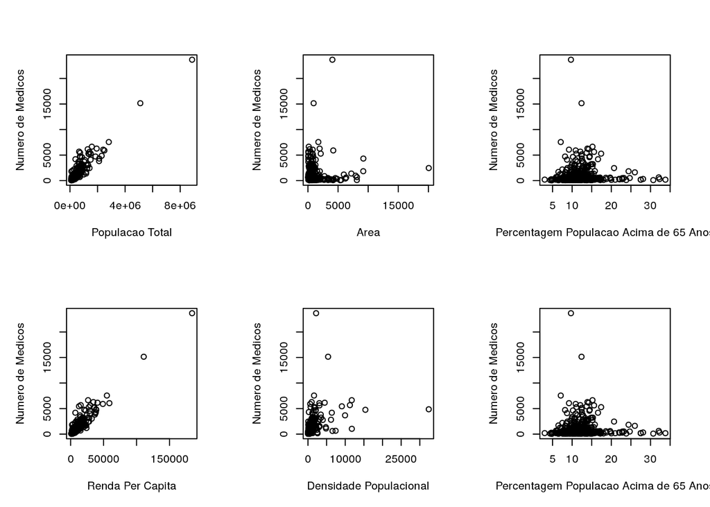

```r
modelo.ex628 = vector("list", length = 2)
dens_Pop = Total_Pop/Land_Area

modelo.ex628[[1]] = lm(num_Phys ~ Total_Pop + Land_Area + Total_Person_Inc)
modelo.ex628[[2]] = lm(num_Phys ~ dens_Pop + Pct_65Plus + Total_Person_Inc)

par(pty="s")
par(mfrow = c(2,3))
plot(x = Total_Pop, y = num_Phys, xlab = "Populacao Total" , ylab = "Numero de Medicos")
plot(Land_Area,num_Phys, xlab = "Area", ylab = "Numero de Medicos")
plot(Pct_65Plus,num_Phys, xlab = "Percentagem Populacao Acima de 65 Anos", ylab = "Numero de Medicos")
plot(Total_Person_Inc,num_Phys, xlab = "Renda Per Capita", ylab = "Numero de Medicos")
plot(dens_Pop,num_Phys, xlab = "Densidade Populacional", ylab = "Numero de Medicos")
plot(Pct_65Plus,num_Phys, xlab = "Percentagem Populacao Acima de 65 Anos", ylab = "Numero de Medicos")
```

```r
summary(modelo.ex628[[1]], correlation = TRUE, digits = 4)$correlation
```

```
##                  (Intercept)  Total_Pop  Land_Area Total_Person_Inc
## (Intercept)       1.00000000 -0.1043109 -0.4018189       0.03998723
## Total_Pop        -0.10431087  1.0000000 -0.2963280      -0.98754297
## Land_Area        -0.40181885 -0.2963280  1.0000000       0.27353962
## Total_Person_Inc  0.03998723 -0.9875430  0.2735396       1.00000000
```

```r
summary(modelo.ex628[[2]], correlation = TRUE, digits = 4)$correlation
```

```
##                  (Intercept)    dens_Pop  Pct_65Plus Total_Person_Inc
## (Intercept)       1.00000000 -0.03223599 -0.93166787      -0.18643003
## dens_Pop         -0.03223599  1.00000000 -0.03834988      -0.31708518
## Pct_65Plus       -0.93166787 -0.03834988  1.00000000       0.03370437
## Total_Person_Inc -0.18643003 -0.31708518  0.03370437       1.00000000
```

## itens c-d

Neste exercício, devemos ajustar um modelo de regressão de múltiplo de primeira ordem
$$Y_i = \sum_{i=0}^{k}X_i \beta_i + \epsilon_i$$
cuja função de regressão será
$$E\{Y_i\} = \sum_{i=0}^{k}X_i \beta_i$$
onde $X_0 = 1$ e $k=3$. O código que realiza a regressão para os modelo1 e modelo2 propostos seguem abaixo.

```r
modelo1 = lm(num_Phys ~ Total_Pop + Land_Area + Total_Person_Inc)
modelo2 = lm(num_Phys ~ Total_Pop/Land_Area + Pct_65Plus + Total_Person_Inc)
```

Adicionalmente, gostariamos de utilizar o $R^2$ múltiplo para ter uma palpite inicial de qual seria o melhor modelo ajustado pela reta de regressão de multipla de primeira ordem. Estes valores para cada modelo são dados a seguir. Note que eles são muito próximos logo, para este exemplo, o $R^2$ múltiplo não nos permite tirar qualquer conclusão.

```r
(summary(modelo1)$r.squared)
```

```
## [1] 0.9026432
```

```r
(summary(modelo2)$r.squared)
```

```
## [1] 0.9040885
```

## item e

```
## Gráficos para o modelo
## Resíduo vs Ajustado
```

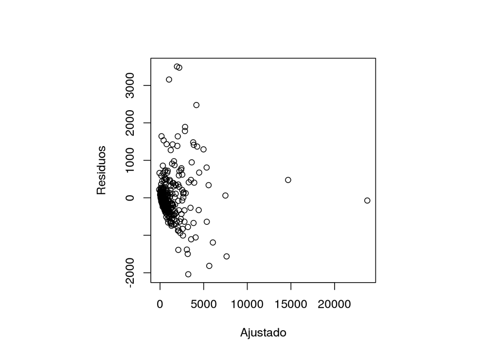

```
## Resíduos vs Preditoras
```

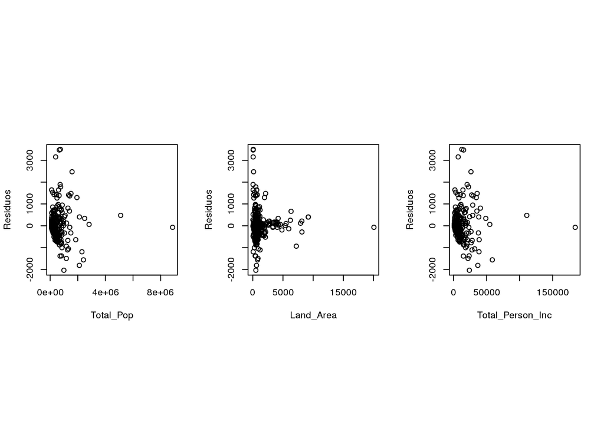

```
## Resíduo vs Interação
```

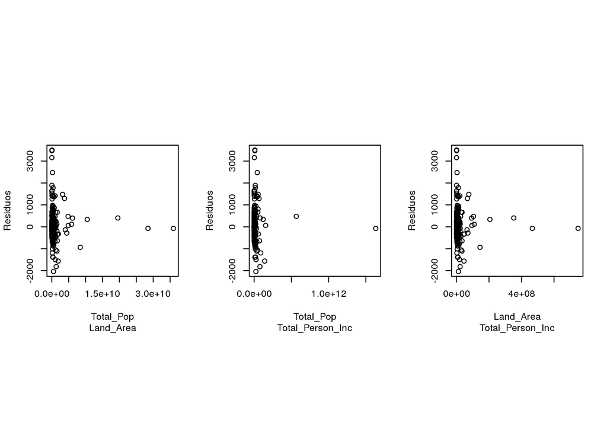

```
## Gráfico de Normalidade
```

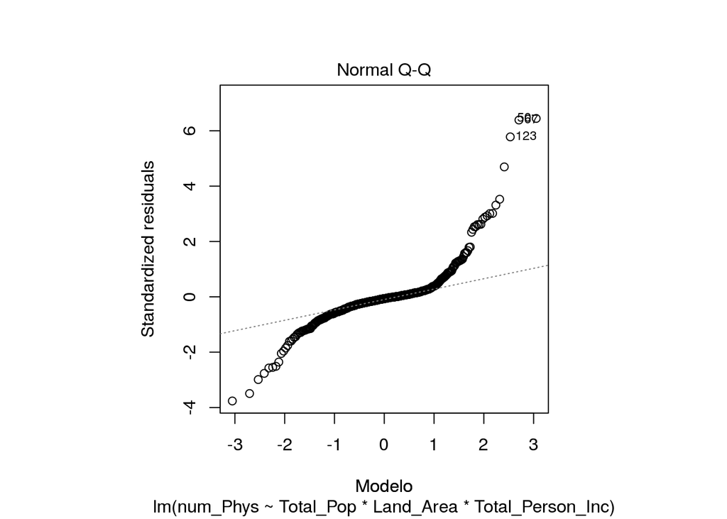

```
## Gráficos para o modelo
## Resíduo vs Ajustado
```

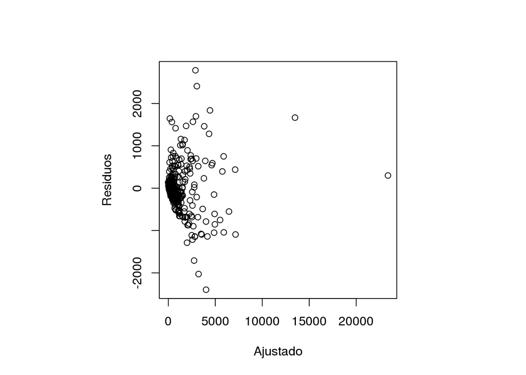

```
## Resíduos vs Preditoras
```

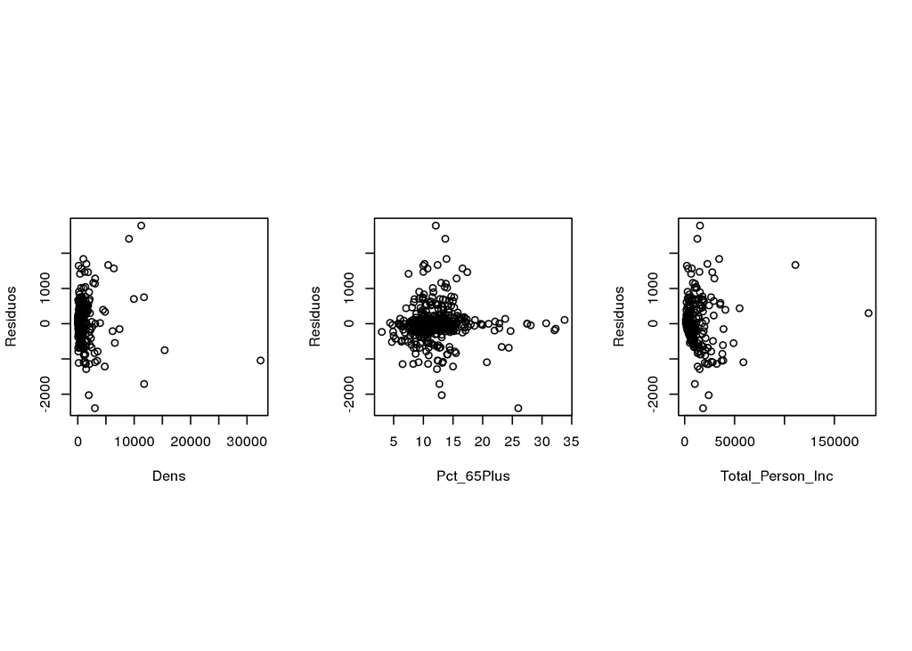

```
## Resíduo vs Interação
```

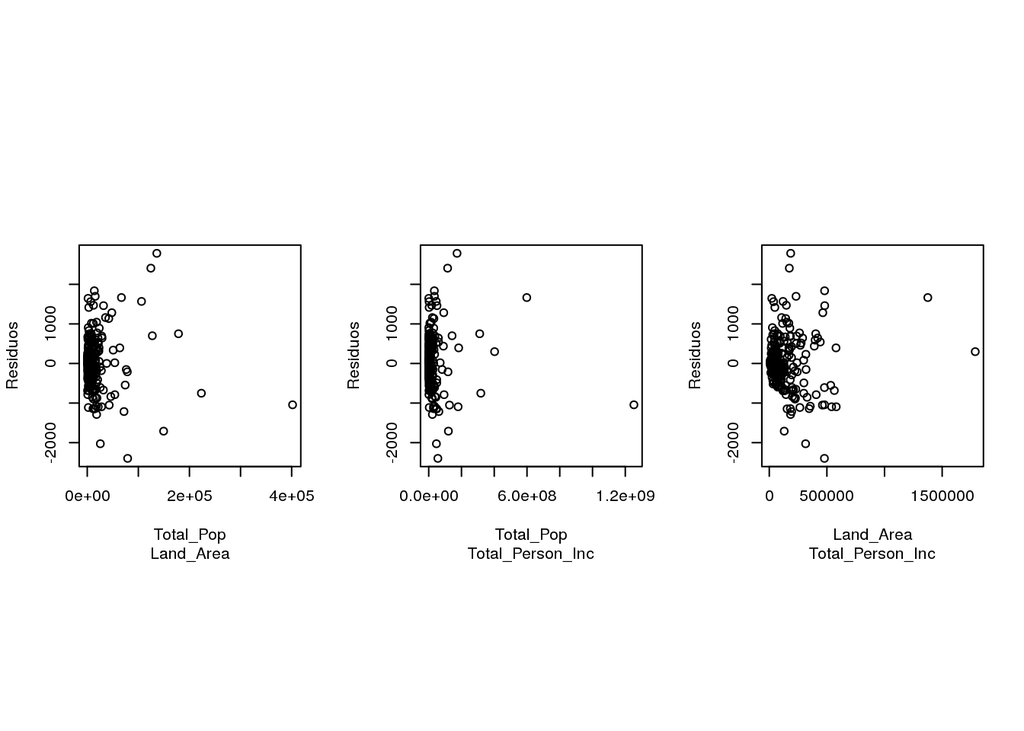

```
## Gráfico de Normalidade
```

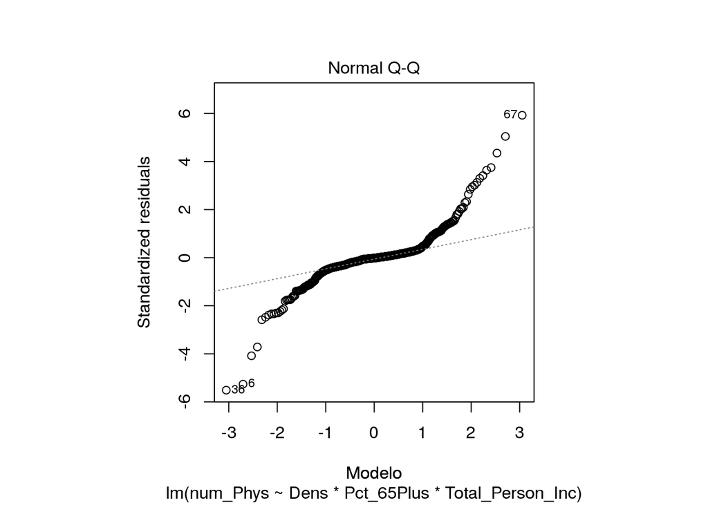

```r
modelo.ex628 = vector("list", 2)
Dens = Total_Pop/Land_Area

modelo.ex628[[1]] = lm(num_Phys ~ Total_Pop*Land_Area*Total_Person_Inc)
modelo.ex628[[2]] = lm(num_Phys ~ Dens*Pct_65Plus*Total_Person_Inc)

for(i in 1:length(modelo.ex628)){
  writeLines("Gráficos para o modelo")

  writeLines("Resíduo vs Ajustado")
  par(pty="s")
  plot(modelo.ex628[[i]]$fitted.values, modelo.ex628[[i]]$residuals, xlab = "Ajustado", ylab=   "Residuos") # Residuals x fitted

  writeLines("Resíduos vs Preditoras")
  par(mfrow = c(1,3))

  for(j in 2:length(modelo.ex628[[i]]$model)){
    par(pty="s")
    plot(data.matrix(modelo.ex628[[i]]$model[j]), modelo.ex628[[i]]$residuals, xlab=colnames(modelo.ex628[[i]]$model)[j], ylab="Residuos") # Residuals x                 Predictors

  }

  comb = combn(c(2,3,4),2)
  writeLines("Resíduo vs Interação")
  par(pty="s")
  par(mfrow = c(1,ncol(comb)))
  for(k in 1:ncol(comb)){
    plot(data.matrix(exp(log(modelo.ex628[[i]]$model[comb[1,k]])+log(modelo.ex628[[i]]$model[comb[2,k]]))), modelo.ex628[[i]]$residuals, ylab = "Residuos", xlab = c(colnames(modelo.ex628[[1]]$model)[comb[1,k]],colnames(modelo.ex628[[1]]$model)[comb[2,k]]))
  }


  writeLines("Gráfico de Normalidade")
  par(mfrow=c(1,1))
  plot(modelo.ex628[[i]], which = 2, xlab="Modelo") # Normal Probability Plot for i-model
}
```

# Exercício 6.29

## itens a-b

Para este exercício, usaremos o conjunto de dados CDI para entender como os números de crimes graves, densidade populacional, renda pessoal total e porcentagem de graduados com ensino médio se relacionam em cada região geográfica. Em especial, faremos uma regressão do número de crimes graves contra as outras variáveis, ou seja, tentaremos explicar o comportamento de Y(número de crimes graves) utilizando $X_1$(densidade populacional), $X_2$(renda pessoal total) e $X_3$(porcentagem de graduados com ensino médio). O modelo proposto para isto será
$$Y_i = \sum_{i=0}^{k}X_i \beta_i + \epsilon_i$$
cuja função de regressão é
$$E\{Y_i\} = \sum_{i=0}^{k}X_i \beta_i$$
onde $X_0 = 1$ e $k=3$. Para este modelo e, para cada um das 4 regiões geográficas (i=4), a técnica de regressão utilizada é dada pelo código abaixo.

```r
modelo1.ex629 = vector("list",max(Geographic_Region))
beta.ex629 = matrix(0,nrow=max(Geographic_Region),ncol=4)
colnames(beta.ex629) = c("beta0","beta1","beta2","beta3")
rownames(beta.ex629) = c("regiao1","regiao2","regiao3","regiao4")
Dens=Total_Pop/Land_Area

for(i in 1:max(Geographic_Region)){
  modelo1.ex629[[i]] = lm(Total_Crimes[which(Geographic_Region ==i)] ~ Dens[which(Geographic_Region==i)] +  Total_Person_Inc[which(Geographic_Region ==i)] + Pct_HSG[which(Geographic_Region==i)])
  beta.ex629[i,] = coef(modelo1.ex629[[i]])
}
(round(beta.ex629,digits = 3))
```

```
##             beta0  beta1 beta2    beta3
## regiao1 -26139.09 16.336 0.383  291.068
## regiao2  63104.12  2.588 3.602 -854.549
## regiao3  56929.39  0.306 4.896 -800.396
## regiao4  37724.58 -0.992 3.627 -489.015
```

Portanto, as funções estimadas $\hat{Y_i}$ são

1. $\hat{{Y_1}_i}$ = -26139.09 + 16.336${X_1}_i$ + 0.383${X_2}_i$ + 291.068${X_3}_i$
2. $\hat{{Y_2}_i}$ = 63104.12 + 2.588${X_1}_i$ + 3.602${X_2}_i$ - 854.549${X_3}_i$
3. $\hat{{Y_3}_i}$ = 56929.39 + 0.306${X_1}_i$ + 4.896${X_2}_i$ - 800.396${X_3}_i$
4. $\hat{{Y_4}_i}$ = 37724.58 - 0.992${X_1}_i$ + 3.627${X_2}_i$ - 489.015${X_3}_i$

Logo, podemos concluir que as únicas funções parecidas nos parâmetros são as funções 2 e 3.

## item c

Os valors dos $R^2$ e MSE para cada região geográfica são dados a seguir.

```r
r2 = rep(0,times=max(Geographic_Region))
MSE.ex629 = rep(0,times=max(Geographic_Region))

for(i in 1:max(Geographic_Region)){
  r2[i] = summary(modelo1.ex629[[i]])$r.squared
  MSE.ex629[i] = summary(modelo1.ex629[[i]])$sigma^2
}
```

```
##                regiao1      regiao2      regiao3      regiao4
## r2                0.83         0.94         0.87         0.97
## MSE.ex629 807279589.89 140169093.43 197074515.96 210421819.84
```

Ao ver os resultados de $R^2$ e $MSE$ por região podemos ver que os valores de $R^2$ estão altos mas não tão próximos, ao passo que, para os $MSE$, podemos notar uma grande variância. Portanto, podemos concluir que as similaridades entre regiões, para estes aspectos, só são preservadas para algumas regiões específicas nos valores de $R^2$.

## item d

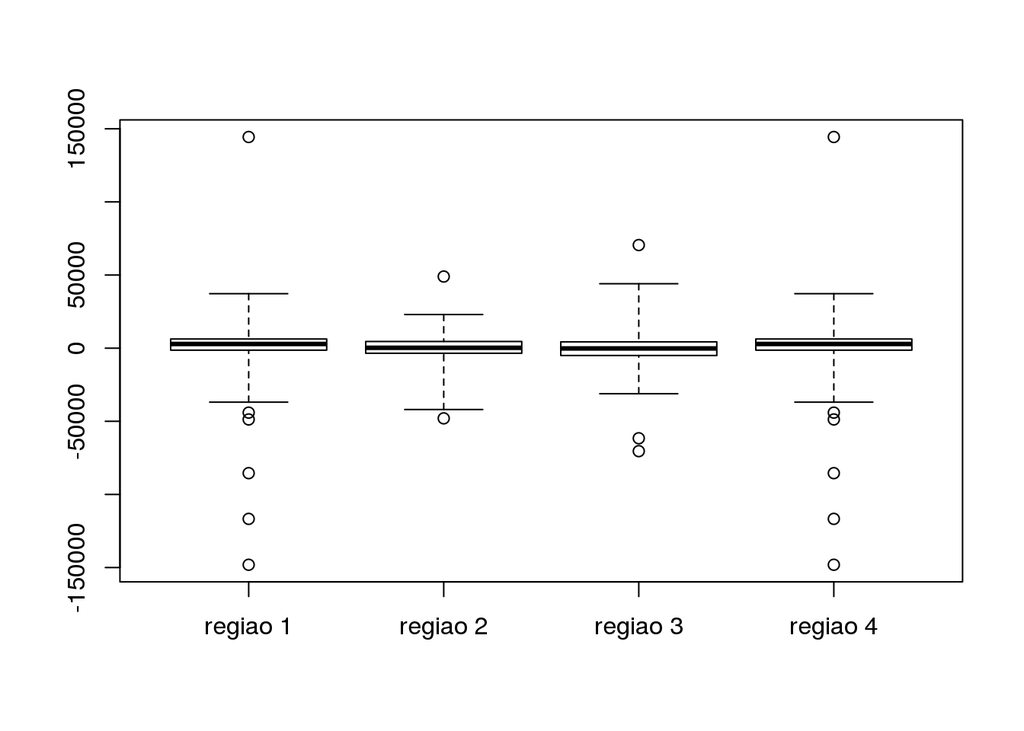

```r
boxplot(modelo1.ex629[[1]]$residuals,modelo1.ex629[[2]]$residuals,modelo1.ex629[[3]]$residuals,modelo1.ex629[[1]]$residuals, range=5, names=c("regiao 1","regiao 2","regiao 3","regiao 4"))
```